# CSF Spectronaut precursor-swap benchmark — visualizing the swap

Author

Generated to accompany swap_spectronaut_report.py

This notebook visualises the CSF Spectronaut dilution dataset after the **precursor-intensity swap** that perturbs ~5 % of proteins as up-regulated and ~5 % as down-regulated between two randomly chosen halves (G1, G2) of each dilution’s runs. Read alongside the swap script `../swap_spectronaut_report.py` and the plan at `/Users/wolski/.claude/plans/just-to-make-sure-cheeky-sprout.md`.

```r
library(data.table)
library(dplyr)
library(ggplot2)
library(stringr)
library(tidyr)
library(patchwork)

theme_set(theme_minimal(base_size = 11))

REPORT_NAME = "20250130_163144_CSF dilutions Jan 2025 no normalization_Report.tsv"
swap_path   = file.path(".", REPORT_NAME)
orig_path   = file.path("..", "CSF_Spectronaut", REPORT_NAME)
groups      = fread(sub(".tsv$", "_swap_group_annotation.csv", REPORT_NAME))
tp          = fread(sub(".tsv$", "_swap_true_positives.tsv", REPORT_NAME))
gt          = fread(sub(".tsv$", "_swap_ground_truth.tsv", REPORT_NAME))
```

# 1. Run schedule and G1/G2 assignment

Each row is one MS run. `R.Replicate` (the trailing `Seq<N>` in the filename) is the injection order; runs are split into G1 / G2 within each dilution condition, and the swap is applied only to G2 runs of the ~10 % perturbed proteins.

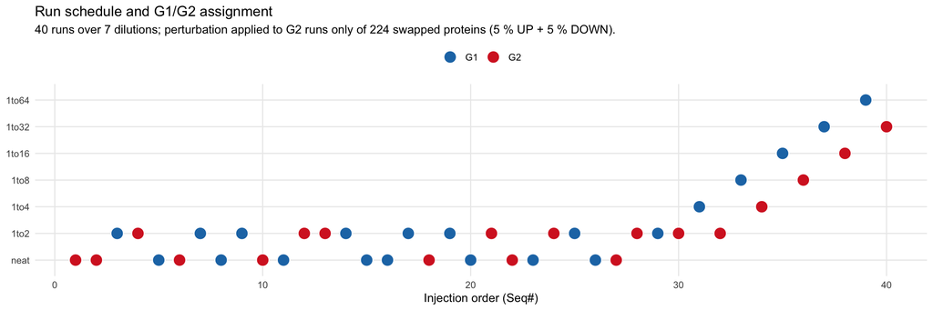

```r
groups[, Order := as.integer(str_extract(R.FileName, "(?<=Seq)\\d+"))]
groups[, Dilution := R.Condition]

dilution_levels = c("neat", "1to2", "1to4", "1to8", "1to16", "1to32", "1to64")
groups[, Dilution := factor(Dilution, levels = dilution_levels)]

ggplot(groups, aes(x = Order, y = Dilution, fill = group)) +
  geom_point(shape = 21, size = 5, colour = "white", stroke = 0.6) +
  scale_fill_manual(values = c("G1" = "#1f77b4", "G2" = "#d62728")) +
  labs(title    = "Run schedule and G1/G2 assignment",
       subtitle = sprintf("%d runs over %d dilutions; perturbation applied to G2 runs only of %d swapped proteins (5 %% UP + 5 %% DOWN).",
                          nrow(groups), uniqueN(groups$Dilution), nrow(tp)),
       x = "Injection order (Seq#)", y = NULL, fill = NULL) +
  theme(legend.position = "top",
        panel.grid.minor.x = element_blank())
```

# 2. Load reports and summarize to protein × run intensities

We summarize the precursor-level Spectronaut report to one log2 intensity per `(protein, run)` by taking the mean of `log2(FG.Quantity)` over precursors. This is a lightweight stand-in for MSstats `dataProcess` and is sufficient for the diagnostic plots that follow.

```r
summarize_report = function(path) {
  dt = fread(path, sep = "\t", select = c("R.FileName", "R.Condition",
                                            "PG.ProteinGroups",
                                            "EG.PrecursorId", "FG.Quantity"))
  dt = dt[!is.na(FG.Quantity) & FG.Quantity > 0]
  dt = unique(dt, by = c("R.FileName", "PG.ProteinGroups", "EG.PrecursorId"))
  dt[, LogQuantity := log2(FG.Quantity)]
  dt[, .(LogIntensity = mean(LogQuantity)),
     by = .(R.FileName, R.Condition, Protein = PG.ProteinGroups)]
}

prot_after  = summarize_report(swap_path); prot_after[, state  := "after swap"]
prot_before = summarize_report(orig_path); prot_before[, state := "before swap"]
prot_all = rbindlist(list(prot_before, prot_after), use.names = TRUE)

prot_all = merge(prot_all, groups[, .(R.FileName, group)],
                  by = "R.FileName", all.x = TRUE)
prot_all = merge(prot_all, tp[, .(Protein = PG.ProteinGroups, role)],
                  by = "Protein", all.x = TRUE)
prot_all[is.na(role), role := "null"]
prot_all[, role := factor(role, levels = c("up", "down", "null"))]
prot_all[, state := factor(state, levels = c("before swap", "after swap"))]

# All downstream analyses run on a single dilution where G1/G2 has enough
# replicates to estimate within-group variance (other dilutions are 1-2 runs).
FOCAL_DILUTION = "neat"
prot_focal = prot_all[R.Condition == FOCAL_DILUTION]
cat(sprintf("Focal dilution: %s — %d runs (%d G1 + %d G2)\n",
            FOCAL_DILUTION,
            uniqueN(prot_focal$R.FileName),
            uniqueN(prot_focal[group == "G1", R.FileName]),
            uniqueN(prot_focal[group == "G2", R.FileName])))
```

```
Focal dilution: neat — 15 runs (8 G1 + 7 G2)
```

# 3. Heatmap after the swap (focal dilution)

Rows are proteins, columns are the runs of the focal dilution (neat) sorted by group (G1 on the left, G2 on the right). The top facet is UP-perturbed proteins, middle is DOWN-perturbed, bottom is a sample of null proteins. Each row is z-scored — red = high, grey = at the row mean, green = low.

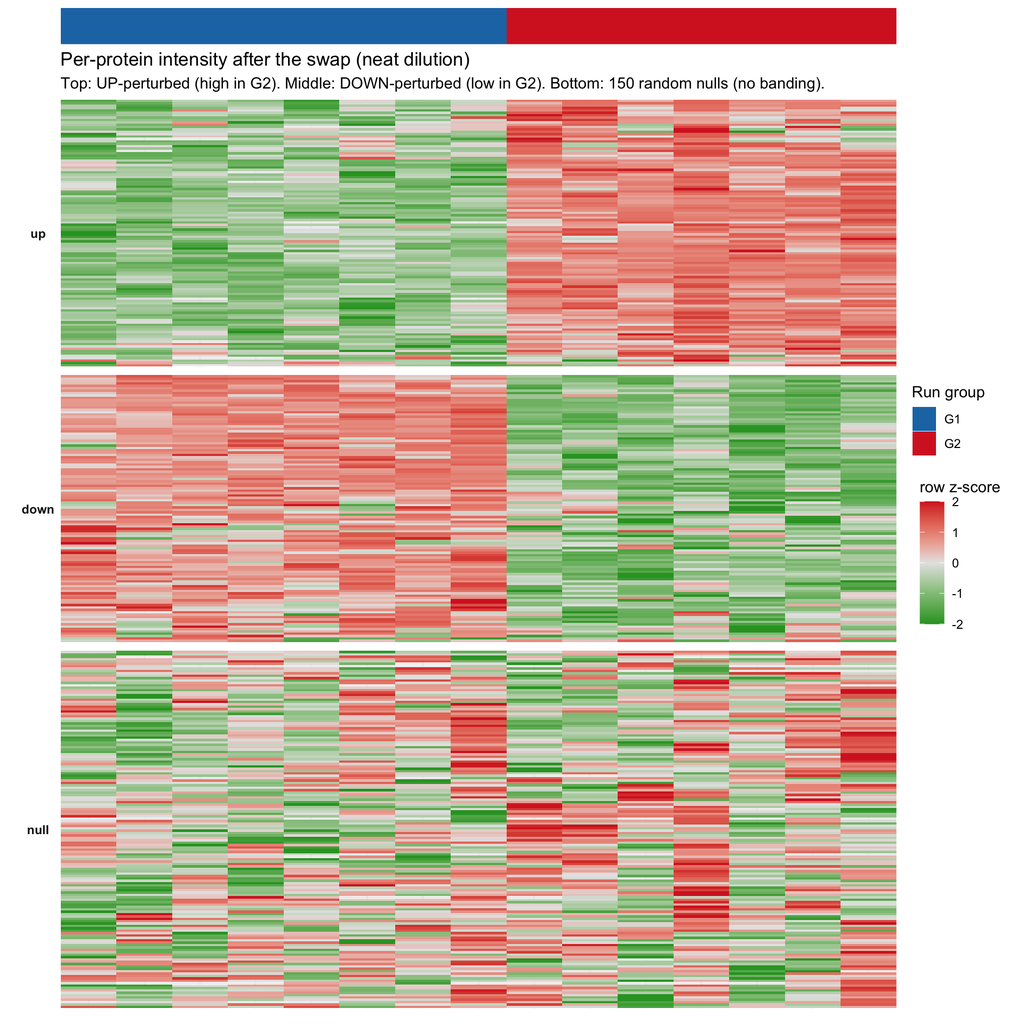

```r
runs_focal = groups[Dilution == FOCAL_DILUTION][order(group, Order),
                                                  .(R.FileName, group, Order)]

prot_h = prot_focal[state == "after swap" &
                      R.FileName %in% runs_focal$R.FileName]

# z-score per protein
prot_h[, z := scale(LogIntensity)[, 1], by = Protein]
prot_h[, z := pmax(pmin(z, 2), -2)]

# Cluster rows within each class
make_row_order = function(dat) {
  if (nrow(dat) < 2 || uniqueN(dat$Protein) < 2) return(unique(dat$Protein))
  m = dcast(dat, Protein ~ R.FileName, value.var = "z")
  mat = as.matrix(m[, -1, with = FALSE])
  mat[is.na(mat)] = 0
  ord = hclust(dist(mat))$order
  m$Protein[ord]
}

set.seed(1)
null_sample = sample(unique(prot_h[role == "null", Protein]),
                      size = min(150, uniqueN(prot_h[role == "null", Protein])))
prot_h = prot_h[role != "null" | Protein %in% null_sample]

ords = c(make_row_order(prot_h[role == "up"]),
         make_row_order(prot_h[role == "down"]),
         make_row_order(prot_h[role == "null"]))
prot_h[, Protein := factor(Protein, levels = ords)]
prot_h[, R.FileName := factor(R.FileName, levels = runs_focal$R.FileName)]

col_strip = runs_focal[, .(R.FileName = factor(R.FileName,
                                                  levels = runs_focal$R.FileName),
                            group)]
p_strip = ggplot(col_strip, aes(x = R.FileName, y = 1, fill = group)) +
  geom_tile() +
  scale_fill_manual(values = c("G1" = "#1f77b4", "G2" = "#d62728"),
                    name = "Run group") +
  scale_x_discrete(expand = c(0, 0)) +
  scale_y_continuous(expand = c(0, 0)) +
  labs(x = NULL, y = NULL) +
  theme_void() +
  theme(legend.position = "top",
        plot.margin = margin(t = 0, r = 0, b = 0, l = 0))

p_heat = ggplot(prot_h, aes(x = R.FileName, y = Protein, fill = z)) +
  geom_tile() +
  facet_grid(role ~ ., scales = "free_y", space = "free_y", switch = "y") +
  scale_fill_gradient2(low = "#2ca02c", mid = "grey90", high = "#d62728",
                       midpoint = 0, limits = c(-2, 2),
                       name = "row z-score") +
  scale_x_discrete(expand = c(0, 0)) +
  labs(title    = sprintf("Per-protein intensity after the swap (%s dilution)",
                            FOCAL_DILUTION),
       subtitle = "Top: UP-perturbed (high in G2). Middle: DOWN-perturbed (low in G2). Bottom: 150 random nulls (no banding).",
       x = NULL, y = NULL) +
  theme(axis.text.x = element_blank(),
        axis.ticks.x = element_blank(),
        axis.text.y = element_blank(),
        axis.ticks.y = element_blank(),
        strip.text.y.left = element_text(angle = 0, face = "bold"),
        legend.position = "right",
        panel.spacing.y = unit(0.4, "lines"))

p_strip / p_heat + plot_layout(heights = c(0.04, 1), guides = "collect") &
  theme(legend.position = "right")
```

**What to see:**

- **UP facet** — within each row, the G2 columns (right half) are red and the G1 columns (left half) are green. The protein received a higher-abundance partner’s intensities in G2.
- **DOWN facet** — mirror image: G2 columns green, G1 red.
- **null facet** — no consistent left-right pattern; cells scatter around the protein mean.

# 4. Per-protein effect size

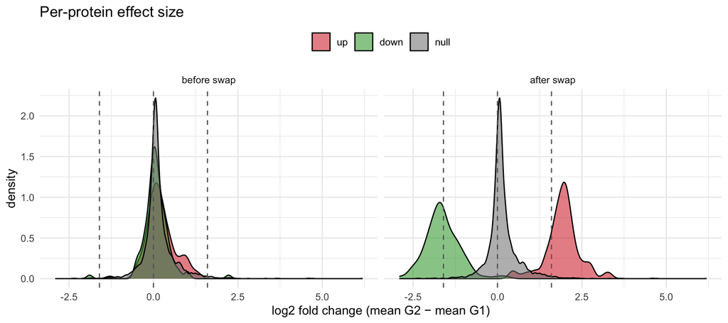

```r
stats = prot_focal[!is.na(group),
                    .(mean_log = mean(LogIntensity, na.rm = TRUE),
                       n = .N),
                    by = .(Protein, group, state, role)]
wide = dcast(stats, Protein + state + role ~ group, value.var = "mean_log")
wide[, mean_diff := G2 - G1]

ggplot(wide[is.finite(mean_diff)], aes(x = mean_diff, fill = role)) +
  geom_density(alpha = 0.55) +
  geom_vline(xintercept = c(-1.6, 0, 1.6), linetype = 2, colour = "grey40") +
  facet_wrap(~ state) +
  scale_fill_manual(values = c("up"   = "#d62728",
                                "down" = "#2ca02c",
                                "null" = "#7f7f7f")) +
  labs(title = "Per-protein effect size",
       x = "log2 fold change (mean G2 − mean G1)", y = "density",
       fill = NULL) +
  theme(legend.position = "top")
```

# 5. Realized vs expected log2 FC for perturbed proteins

Scatter of the **realized** per-protein log2FC (G2 − G1, after swap) against the **expected** log2FC recorded in the ground-truth file. Should track the identity line within the precursor-level noise; the spread comes mainly from missing-value patterns at the precursor level.

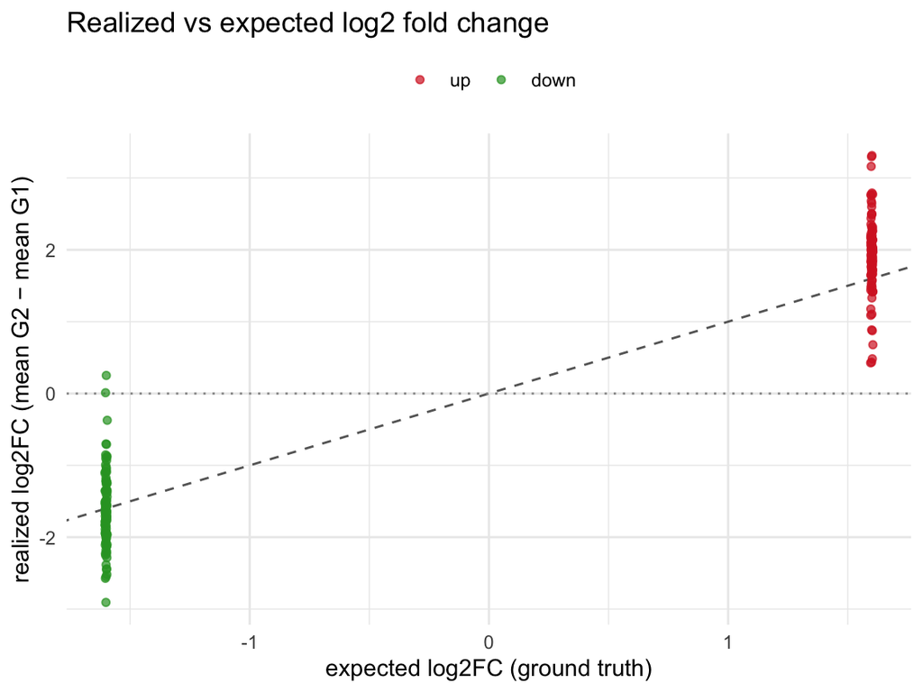

```r
sw = merge(
  wide[state == "after swap" & role != "null",
        .(Protein, role, mean_diff)],
  tp[, .(Protein = PG.ProteinGroups, expected_log2fc)],
  by = "Protein"
)

ggplot(sw, aes(x = expected_log2fc, y = mean_diff, colour = role)) +
  geom_abline(slope = 1, intercept = 0, linetype = 2, colour = "grey40") +
  geom_hline(yintercept = 0, linetype = 3, colour = "grey60") +
  geom_point(alpha = 0.7, size = 1.4) +
  scale_colour_manual(values = c("up" = "#d62728", "down" = "#2ca02c")) +
  labs(title = "Realized vs expected log2 fold change",
       x = "expected log2FC (ground truth)",
       y = "realized log2FC (mean G2 − mean G1)",
       colour = NULL) +
  theme(legend.position = "top")
```

```r
cat(sprintf("Pearson r = %.3f\n",
            cor(sw$expected_log2fc, sw$mean_diff, use = "complete.obs")))
```

```
Pearson r = 0.962
```

# 6. Within-group variance

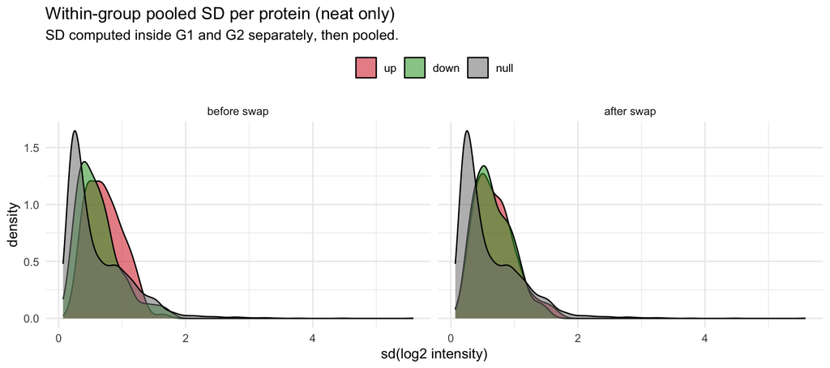

```r
stats2 = prot_focal[!is.na(group),
                     .(sd_log = sd(LogIntensity, na.rm = TRUE),
                        n      = .N),
                     by = .(Protein, group, state, role)]

# Pool the two within-group cells (G1 and G2) per protein × state.
sd_within = stats2[is.finite(sd_log) & n >= 2,
                   .(sd_pool = sqrt(sum((n - 1) * sd_log^2) /
                                     pmax(sum(n - 1), 1)),
                     n_cells = .N),
                   by = .(Protein, state, role)]

ggplot(sd_within[n_cells == 2], aes(x = sd_pool, fill = role)) +
  geom_density(alpha = 0.55) +
  facet_wrap(~ state) +
  scale_fill_manual(values = c("up"   = "#d62728",
                                "down" = "#2ca02c",
                                "null" = "#7f7f7f")) +
  labs(title    = sprintf("Within-group pooled SD per protein (%s only)",
                           FOCAL_DILUTION),
       subtitle = "SD computed inside G1 and G2 separately, then pooled.",
       x = "sd(log2 intensity)", y = "density", fill = NULL) +
  theme(legend.position = "top")
```

# 7. Mean–variance relationship (SD vs mean intensity)

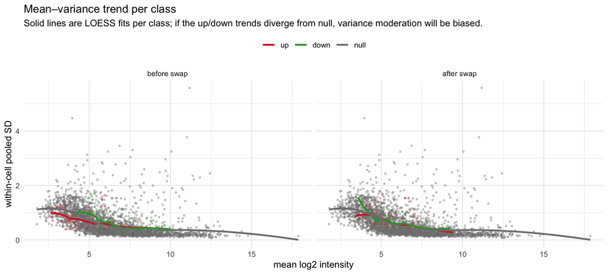

```r
mean_int = prot_focal[!is.na(group),
                       .(mean_intensity = mean(LogIntensity, na.rm = TRUE)),
                       by = .(Protein, state)]
mv = merge(sd_within[n_cells == 2], mean_int, by = c("Protein", "state"))

ggplot(mv, aes(x = mean_intensity, y = sd_pool, colour = role)) +
  geom_point(alpha = 0.35, size = 0.7) +
  geom_smooth(se = FALSE, method = "loess", span = 0.6) +
  facet_wrap(~ state) +
  scale_colour_manual(values = c("up"   = "#d62728",
                                  "down" = "#2ca02c",
                                  "null" = "#7f7f7f")) +
  labs(title    = "Mean–variance trend per class",
       subtitle = "Solid lines are LOESS fits per class; if the up/down trends diverge from null, variance moderation will be biased.",
       x = "mean log2 intensity", y = "within-cell pooled SD",
       colour = NULL) +
  theme(legend.position = "top")
```

# 8. Take-aways

1. The swap perturbs ~5 % of proteins as UP and ~5 % as DOWN; the remaining ~90 % are an empirical null with G2/G1 log2FC centered on 0.
2. Realized log2FC for perturbed proteins tracks the expected ±1.6 with high correlation; the residual spread comes from missing-value patterns at the precursor level — unavoidable when working from real DIA quant.
3. Variance for perturbed proteins is inflated relative to nulls, by the same mechanism. Empirical-Bayes variance moderation (limma, DEqMS) trained on the full population will be biased toward the inflated variance and may over-shrink perturbed estimates — same caveat as the original run-pair swap design.